# Statistical Analysis Excercise 1

Rohit Gupta

June 2, 2017

## Overview

```r
library(knitr)
library(ggplot2)
# knitr settings
knitr::opts_chunk$set(echo=TRUE, fig.path='part1/', fig.width=10, fig.height=6, cache=TRUE)
# seed
set.seed(12345)
```

## Simulation

The exponential distribution is simulated in R with rexp(n, lambda) where lambda is the rate parameter. The mean of exponential distribution is 1/lambda and the standard deviation is also 1/lambda. Set lambda = 0.2 for all of the simulations.

```r
lambda <- 0.2
sample_size <- 40
simulations <- 1000
sim_matrix <- matrix(rexp(simulations*sample_size, rate=lambda), simulations, sample_size)
```

The simulation mean can now be plotted below to further explore.

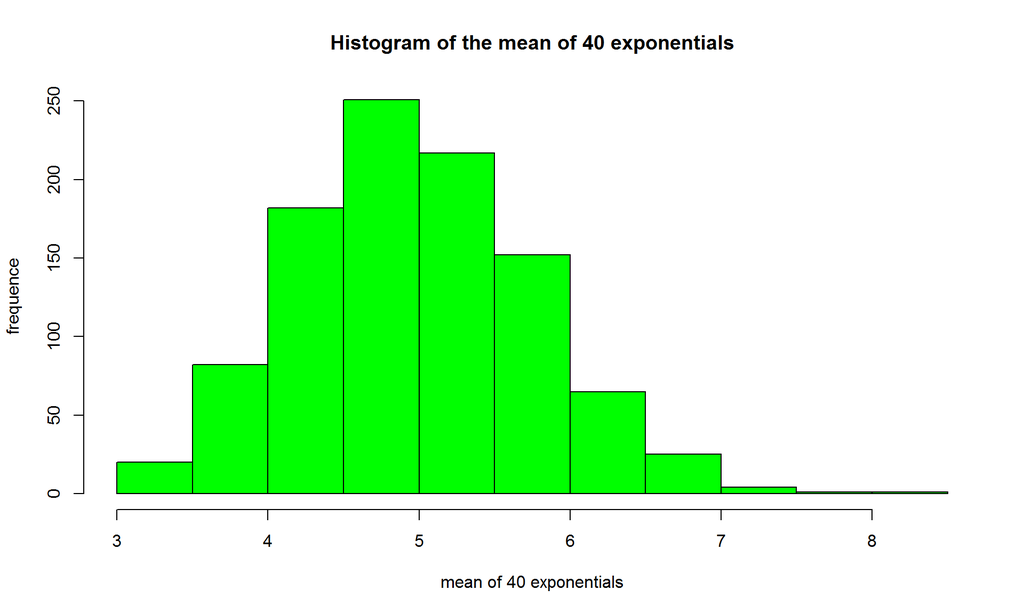

```r
sim_mean <- rowMeans(sim_matrix)
hist(sim_mean, xlab="mean of 40 exponentials", ylab="frequence", main="Histogram of the mean of 40 exponentials", col="green")
```

## Sample Mean vs. Theoretical Mean

```r
sample_mean <- mean(sim_mean)
cat("sample mean: ", sample_mean)
```

```
## sample mean:  4.971972
```

```r
theoretical_mean <- 1/lambda
cat("theoretical mean: ", theoretical_mean)
```

```
## theoretical mean:  5
```

As shown, the sample mean is very close to the expected theoretical mean.

## Sample Variance vs. Theoretical Variance

```r
sample_var <- var(sim_mean)
cat("sample variance: ", sample_var)
```

```
## sample variance:  0.6157926
```

```r
theoretical_var <- (1/lambda)^2/sample_size
cat("theoretical variance: ", theoretical_var)
```

```
## theoretical variance:  0.625
```

Again they are very close.

## Distribution

First, we create an approximate normal distribution and see how the sample aligns with it

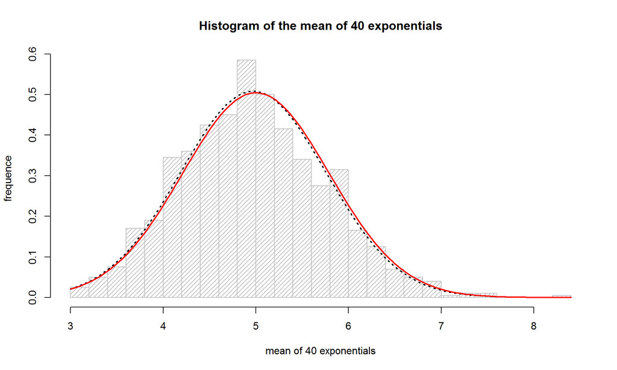

```r
hist(sim_mean, density=20, breaks=20, prob=TRUE, xlab="mean of 40 exponentials", ylab="frequence", main="Histogram of the mean of 40 exponentials", col="grey")
curve(dnorm(x, mean=sample_mean, sd=sqrt(sample_var)), col="black", lwd=2, lty = "dotted", add=TRUE, yaxt="n")
curve(dnorm(x, mean=theoretical_mean, sd=sqrt(theoretical_var)), col="red", lwd=2, add=TRUE, yaxt="n")
```

The plot above shows the histogram can be approximated with the normal distribution.

Second, we have proved that the mean and variance of sample data close to those of normal distribution. Below shows the confidence intervals:

```r
sample_conf_interval <- round (mean(sim_mean) + c(-1,1)*1.96*sd(sim_mean)/sqrt(sample_size),3)
cat("sample confidence interval: ", sample_conf_interval)
```

```
## sample confidence interval:  4.729 5.215
```

```r
theory_conf_interval <- theoretical_mean + c(-1,1)*1.96*sqrt(theoretical_var)/sqrt(sample_size);
cat("theoretical confidence interval: ", theory_conf_interval)
```

```
## theoretical confidence interval:  4.755 5.245
```

Third, plot Q-Q for quantiles

The sample quantiles also match closely with the theorietical quantiles.

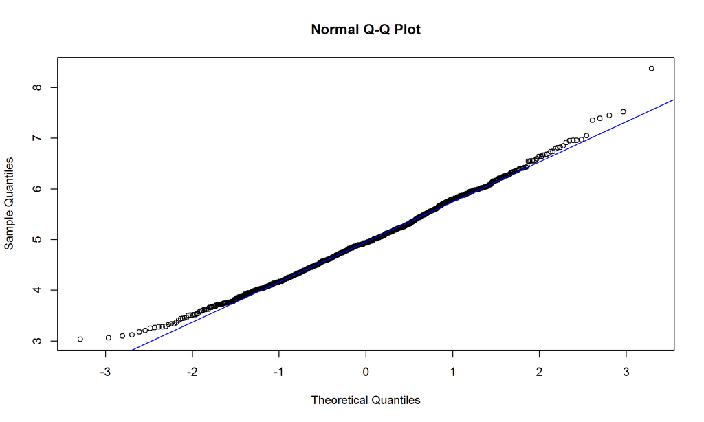

```r
qqnorm(sim_mean, main="Normal Q-Q Plot", xlab="Theoretical Quantiles", ylab="Sample Quantiles")
qqline(sim_mean, col="blue")
```